# Analysis of ARMA(p,q) Processes

2025-08-07

# Introduction to ARMA(p,q) Processes

ARMA(p,q) processes combine both Autoregressive (AR) and Moving Average (MA) components:

$$Y_t = \phi_1 Y_{t-1} + \phi_2 Y_{t-2} +
... + \phi_p Y_{t-p} + \epsilon_t + \theta_1 \epsilon_{t-1} + ... +
\theta_q \epsilon_{t-q}$$

Or in compact form: $\Phi(L)Y_t = \Theta(L)\epsilon_t$

**Key advantages of ARMA models:**

-**Parsimony**: Can model complex patterns with fewer parameters than pure AR or MA

-**Flexibility**: Combines persistence (AR) with shock effects (MA)

-**Identification**: ACF and PACF patterns help determine appropriate orders

```r
# Simulation parameters
n_obs <- 400
time_points <- 1:n_obs
```

## ARMA(1,1) Process

The simplest mixed model: $Y_t = \phi_1 Y_{t-1} + \epsilon_t + \theta_1 \epsilon_{t-1}$

**Properties:** - Combines AR(1) persistence with MA(1) shock smoothing - Always stationary if $|\phi_1| < 1$ (AR condition) - Invertible if $|\theta_1| < 1$ (MA condition)

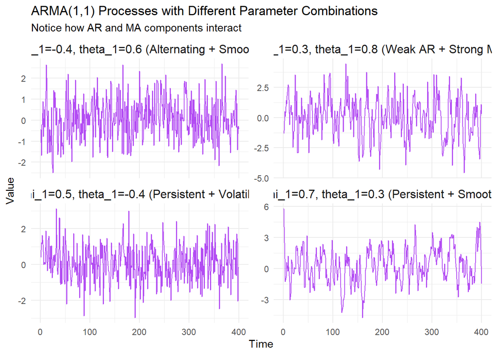

```r
# Different ARMA(1,1) parameter combinations
arma11_params <- list(
  list(ar = 0.7, ma = 0.3, label = "phi_1=0.7, theta_1=0.3 (Persistent + Smooth)"),
  list(ar = 0.5, ma = -0.4, label = "phi_1=0.5, theta_1=-0.4 (Persistent + Volatile)"),
  list(ar = -0.4, ma = 0.6, label = "phi_1=-0.4, theta_1=0.6 (Alternating + Smooth)"),
  list(ar = 0.3, ma = 0.8, label = "phi_1=0.3, theta_1=0.8 (Weak AR + Strong MA)")
)

arma11_data <- data.frame()

for (params in arma11_params) {
  # Using arima.sim for accurate ARMA simulation
  series <- as.numeric(arima.sim(n = n_obs,
                                list(ar = params$ar, ma = params$ma),
                                sd = 1))
  temp_df <- data.frame(
    time = time_points,
    value = series,
    params = params$label,
    process = "ARMA(1,1)"
  )
  arma11_data <- rbind(arma11_data, temp_df)
}

# Plot ARMA(1,1) processes
p1 <- ggplot(arma11_data, aes(x = time, y = value)) +
  geom_line(color = "purple", alpha = 0.8) +
  facet_wrap(~params, scales = "free_y", ncol = 2) +
  labs(title = "ARMA(1,1) Processes with Different Parameter Combinations",
       subtitle = "Notice how AR and MA components interact",
       x = "Time", y = "Value") +
  theme_minimal() +
  theme(strip.text = element_text(size = 12))

print(p1)
```

## ACF/PACF Patterns: Some help for ARMA Identification

ARMA processes have characteristic ACF and PACF patterns: - **ACF**: Decays gradually (mix of exponential and oscillatory) - **PACF**: Decays gradually (opposite of pure AR or MA)

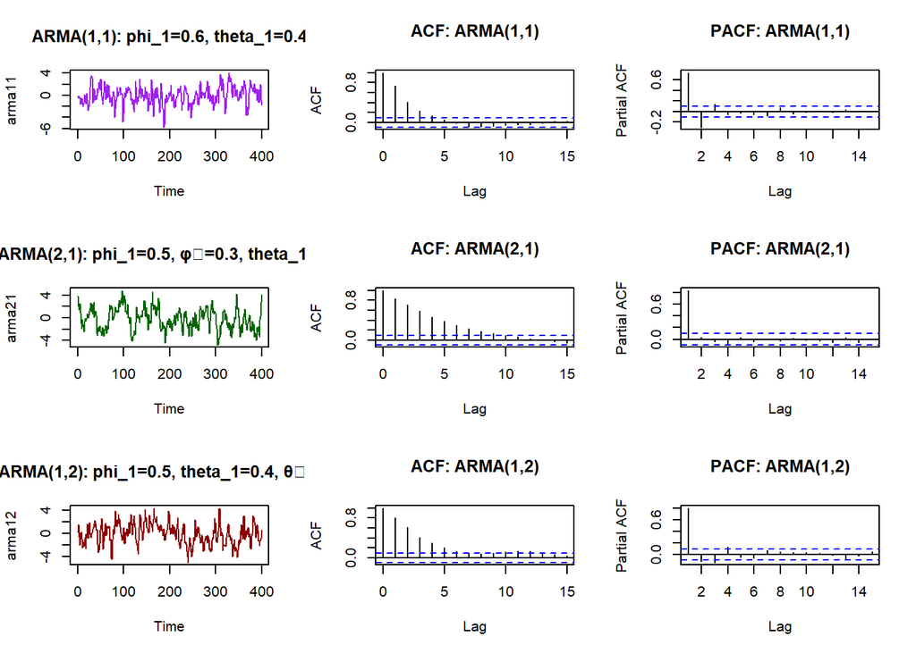

```r
# Generate examples for identification
set.seed(789)

# ARMA(1,1)
arma11 <- arima.sim(n = n_obs, list(ar = 0.6, ma = 0.4))
# ARMA(2,1)
arma21 <- arima.sim(n = n_obs, list(ar = c(0.5, 0.3), ma = 0.4))
# ARMA(1,2)
arma12 <- arima.sim(n = n_obs, list(ar = 0.5, ma = c(0.4, 0.3)))

# Plot ACF and PACF
par(mfrow = c(3, 3))

# ARMA(1,1)
plot(arma11, main = "ARMA(1,1): phi_1=0.6, theta_1=0.4", col = "purple")
acf(arma11, main = "ACF: ARMA(1,1)", lag.max = 15)
pacf(arma11, main = "PACF: ARMA(1,1)", lag.max = 15)

# ARMA(2,1)
plot(arma21, main = "ARMA(2,1): phi_1=0.5, φ₂=0.3, theta_1=0.4", col = "darkgreen")
acf(arma21, main = "ACF: ARMA(2,1)", lag.max = 15)
pacf(arma21, main = "PACF: ARMA(2,1)", lag.max = 15)

# ARMA(1,2)
plot(arma12, main = "ARMA(1,2): phi_1=0.5, theta_1=0.4, θ₂=0.3", col = "darkred")
acf(arma12, main = "ACF: ARMA(1,2)", lag.max = 15)
pacf(arma12, main = "PACF: ARMA(1,2)", lag.max = 15)
```

```r
par(mfrow = c(1, 1))
```

## Comparison: AR vs MA vs ARMA

Let’s compare how different model types capture the same underlying pattern:

```r
# Generate a complex ARMA(2,1) process
set.seed(123)
complex_series <- arima.sim(n = 300, list(ar = c(0.5, 0.3), ma = 0.4))

# Fit different model types
ar_model <- arima(complex_series, order = c(5, 0, 0))  # High-order AR
ma_model <- arima(complex_series, order = c(0, 0, 5))  # High-order MA
arma_model <- arima(complex_series, order = c(2, 0, 1)) # True model

# Compare AIC
comparison <- data.frame(
  Model = c("AR(5)", "MA(5)", "ARMA(2,1)"),
  AIC = c(AIC(ar_model), AIC(ma_model), AIC(arma_model)),
  Parameters = c(5, 5, 3)
)

print("Model Comparison:")
```

```
## [1] "Model Comparison:"
```

```r
print(comparison)
```

```
##       Model      AIC Parameters
## 1     AR(5) 838.9725          5
## 2     MA(5) 842.0414          5
## 3 ARMA(2,1) 834.0738          3
```

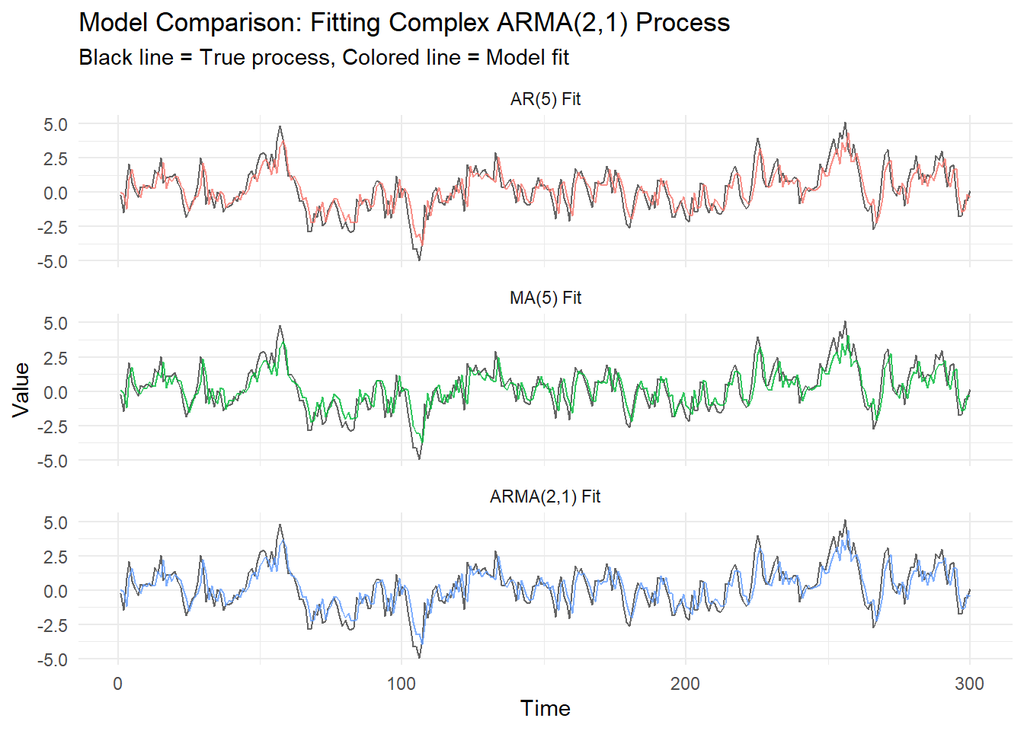

```r
# Plot fitted values
fitted_data <- data.frame(
  time = 1:300,
  observed = as.numeric(complex_series),
  ar_fitted = as.numeric(fitted(ar_model)),
  ma_fitted = as.numeric(fitted(ma_model)),
  arma_fitted = as.numeric(fitted(arma_model))
)

fitted_long <- reshape2::melt(fitted_data, id.vars = c("time", "observed"))

p_comparison <- ggplot(fitted_long) +
  geom_line(aes(x = time, y = observed), color = "black", alpha = 0.6) +
  geom_line(aes(x = time, y = value, color = variable), alpha = 0.8) +
  facet_wrap(~variable, ncol = 1,
             labeller = labeller(variable = c("ar_fitted" = "AR(5) Fit",
                                             "ma_fitted" = "MA(5) Fit",
                                             "arma_fitted" = "ARMA(2,1) Fit"))) +
  labs(title = "Model Comparison: Fitting Complex ARMA(2,1) Process",
       subtitle = "Black line = True process, Colored line = Model fit",
       x = "Time", y = "Value") +
  theme_minimal() +
  theme(legend.position = "none")

print(p_comparison)
```

## Key Takeaways

### **ARMA Model Advantages:**

1. **Parsimony**: ARMA(2,1) captures complex patterns with 3 parameters vs AR(5) or MA(5) with 5 parameters
2. **Interpretability**:
   - AR terms capture **persistence** and **momentum**
   - MA terms capture **shock effects** and **error correction**
3. **Forecasting**: Combines both autoregressive prediction and moving average smoothing